# Populate indicators using data for Western Cape

Katelyn Faulkner

2025-03-06

```r
# Load packages
library(tidyverse) # Data wrangling and visualisation
library(here)      # Relative paths
library(sf)        # Work with spatial data
library(b3gbi)     # Indicators
```

# Goal

Populate indicators using structured data of the Western Cape from the “Southern African Bird Atlas Project 2” (SABAP2).

Populate indicators using unstructured data of the Western Cape

Structured and unstructured data were prepared at both QDGC and pentad scales. Analysis at both scales below

# Load pentad scale data

## Structured data

The SABAP2 data were prepared and stored as a geopackage file in *./data/interim*.

We read in the dataset.

```r
# Data path
data_path <- here::here("data", "interim")
```

```r
# Read SABAP2 Western Cape bird data (5min x 5 min/ 8.2 km x 8.2 km)
SABAP2WCinterim <- read_sf(file.path(data_path, "SABAP2_Pentad_WC_data.gpkg"))

# Explore dataframe
glimpse(SABAP2WCinterim)
```

```
## Rows: 2,146,731
## Columns: 246
## $ pentad                              <chr> "3025_1830", "3025_1830", "3025_18…
## $ `2008`                              <dbl> 0, 0, 0, 0, 0, 0, 0, 0, 0, 0, 0, 0…
## $ `2009`                              <dbl> 0, 0, 0, 0, 0, 0, 0, 0, 0, 0, 0, 0…
## $ `2010`                              <dbl> 0, 0, 0, 0, 0, 0, 0, 0, 0, 0, 0, 0…
## $ `2011`                              <dbl> 0, 0, 0, 0, 0, 0, 0, 0, 0, 0, 0, 0…
## $ `2012`                              <dbl> 0, 0, 0, 0, 0, 0, 0, 0, 0, 0, 0, 0…
## $ `2013`                              <dbl> 2, 2, 2, 2, 2, 2, 2, 2, 2, 2, 2, 2…
## $ `2014`                              <dbl> 0, 0, 0, 0, 0, 0, 0, 0, 0, 0, 0, 0…
## $ `2015`                              <dbl> 0, 0, 0, 0, 0, 0, 0, 0, 0, 0, 0, 0…
## $ `2016`                              <dbl> 0, 0, 0, 0, 0, 0, 0, 0, 0, 0, 0, 0…
## $ `2017`                              <dbl> 0, 0, 0, 0, 0, 0, 0, 0, 0, 0, 0, 0…
## $ `2018`                              <dbl> 0, 0, 0, 0, 0, 0, 0, 0, 0, 0, 0, 0…
## $ `2019`                              <dbl> 0, 0, 0, 0, 0, 0, 0, 0, 0, 0, 0, 0…
```

[output cut: 233 more lines]

## Unstructured data cube

Unstructured data from GBIF were prepared and stored as a geopackage file in *./data/interim*.

We read in the dataset.

```r
# Read unstructured Western Cape bird data (5min x 5 min/ 8.2 km x 8.2 km)
UnstrucWCinterim <- read_sf(file.path(data_path, "birdcube_Pentad_year_WC.gpkg"))

# Explore dataframe
glimpse(UnstrucWCinterim)
```

```
## Rows: 280,854
## Columns: 29
## $ pentad                           <chr> "3035_1840", "3035_1840", "3035_1840"…
## $ `2008`                           <dbl> 0, 0, 0, 0, 0, 0, 0, 0, 0, 0, 0, 0, 0…
## $ `2009`                           <dbl> 0, 0, 0, 0, 0, 0, 0, 0, 0, 0, 0, 0, 0…
## $ `2010`                           <dbl> 1, 1, 1, 1, 1, 1, 1, 1, 1, 1, 1, 1, 1…
## $ `2011`                           <dbl> 1, 1, 1, 1, 1, 1, 1, 1, 1, 1, 1, 1, 1…
## $ `2012`                           <dbl> 1, 1, 1, 1, 1, 1, 1, 1, 1, 1, 1, 1, 1…
## $ `2013`                           <dbl> 2, 2, 2, 2, 2, 2, 2, 2, 2, 2, 2, 2, 2…
## $ `2014`                           <dbl> 1, 1, 1, 1, 1, 1, 1, 1, 1, 1, 1, 1, 1…
## $ `2015`                           <dbl> 2, 2, 2, 2, 2, 2, 2, 2, 2, 2, 2, 2, 2…
## $ `2016`                           <dbl> 1, 1, 1, 1, 1, 1, 1, 1, 1, 1, 1, 1, 1…
## $ `2017`                           <dbl> 0, 0, 0, 0, 0, 0, 0, 0, 0, 0, 0, 0, 0…
## $ `2018`                           <dbl> 0, 0, 0, 0, 0, 0, 0, 0, 0, 0, 0, 0, 0…
## $ `2019`                           <dbl> 2, 2, 2, 2, 2, 2, 2, 2, 2, 2, 2, 2, 2…
```

[output cut: 16 more lines]

# Prepare data for indicators

Structured data from SABAP2 for birds recorded in pentads of Western Cape (1842) between 2008 and 2024.

It was noted that there were 50316 records where ‘species’ was NA. They were removed below.

Also of note is that there is a delay in data feeding into GBIF, and so data for 2024, and most of 2023 is not included in the dataset.

There also seems to be issues for the data for certain species feeding into GBIF (could be related to 50316 records above).

```r
# Drop geometry, removed records not identified to species level
SABAP2WCGeom <-  SABAP2WCinterim %>%
filter(!is.na(species))

SABAP2WC <-  SABAP2WCGeom %>% st_drop_geometry()

# Group by species, year and pentad
SABAP2WCGrp <-SABAP2WC %>%
   group_by(species, year, pentad, speciesKey) %>%
    summarise(n = n())
glimpse(SABAP2WCGrp)
```

```
## Rows: 640,686
## Columns: 5
## Groups: species, year, pentad [640,686]
## $ species    <chr> "Accipiter melanoleucus", "Accipiter melanoleucus", "Accipi…
## $ year       <dbl> 2008, 2008, 2008, 2008, 2008, 2008, 2008, 2008, 2008, 2008,…
## $ pentad     <chr> "3235_1900", "3240_1840", "3255_1930", "3305_1835", "3320_1…
## $ speciesKey <dbl> 2480631, 2480631, 2480631, 2480631, 2480631, 2480631, 24806…
## $ n          <int> 1, 1, 2, 1, 1, 1, 1, 1, 1, 1, 4, 2, 5, 1, 1, 1, 2, 3, 2, 1,…
```

Unstructured data from GBIF for birds recorded in pentads of Western Cape (1842) between 2008 and 2024.

Note delays in data feeding into GBIF mean that the data for 2024 is not complete.

There were several species in the unstructured data that were not in the SABAP2 data. This was due to various issues, including missidentifications, or potential issues with the data for these species feeding into GBIF.

```r
# Remove geometry
UnstrucWC<- UnstrucWCinterim %>%
  st_drop_geometry()
```

```r
# species recorded in sabap2
studied_spec <- unique(SABAP2WC$species) %>%
  na.omit()

UnstrucWCsppGeom <- UnstrucWCinterim %>%
  filter(species %in% studied_spec)

UnstrucWCspp <- UnstrucWCsppGeom %>%
  st_drop_geometry()
```

# Indicators

The indicators have been populated including/excluding species in unstructured data not included in SABAP2

## Unstructured data

### Period 2008-2024 (all species)

```r
# Process cube
WCunstruc <- process_cube(UnstrucWC, grid_type = 'custom', first_year = '2008', cols_year =  'year', cols_cellCode = 'pentad', cols_occurrences = 'n',  cols_minCoordinateUncertaintyInMeters
= 'mincoordinateUncertaintyInMeters', cols_familyCount = 'familycount')
```

### Observed richness

```r
map_obs_rich_WC <- obs_richness_map(WCunstruc, cell_size = 0.08333333, level = "cube", region = "South Africa", ne_scale = "medium")
plot(map_obs_rich_WC)
```

Above will not work as grid (pentads) is custom, cannot map results. Below mapped richness using other methods.

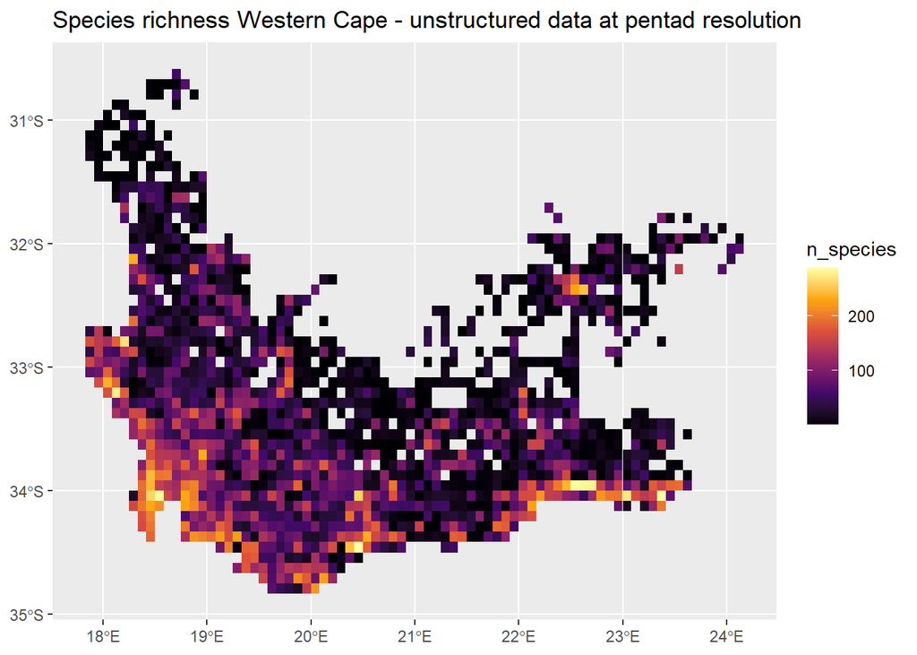

```r
UnstrucWCinterim %>% group_by(pentad) %>%
              summarise(n_species = n_distinct(species), .groups = "drop") %>%
  ggplot() +
    geom_sf(aes(fill = n_species), col = alpha("white", 0)) +
    scale_fill_viridis_c(option = "inferno") +
    ggtitle("Species richness Western Cape - unstructured data at pentad resolution")
```

Change over time

```r
ts_map_obs_rich_WC <- obs_richness_ts(WCunstruc, cell_size = 0.08333333, level = "cube", region = "South Africa", ne_scale = "medium")
```

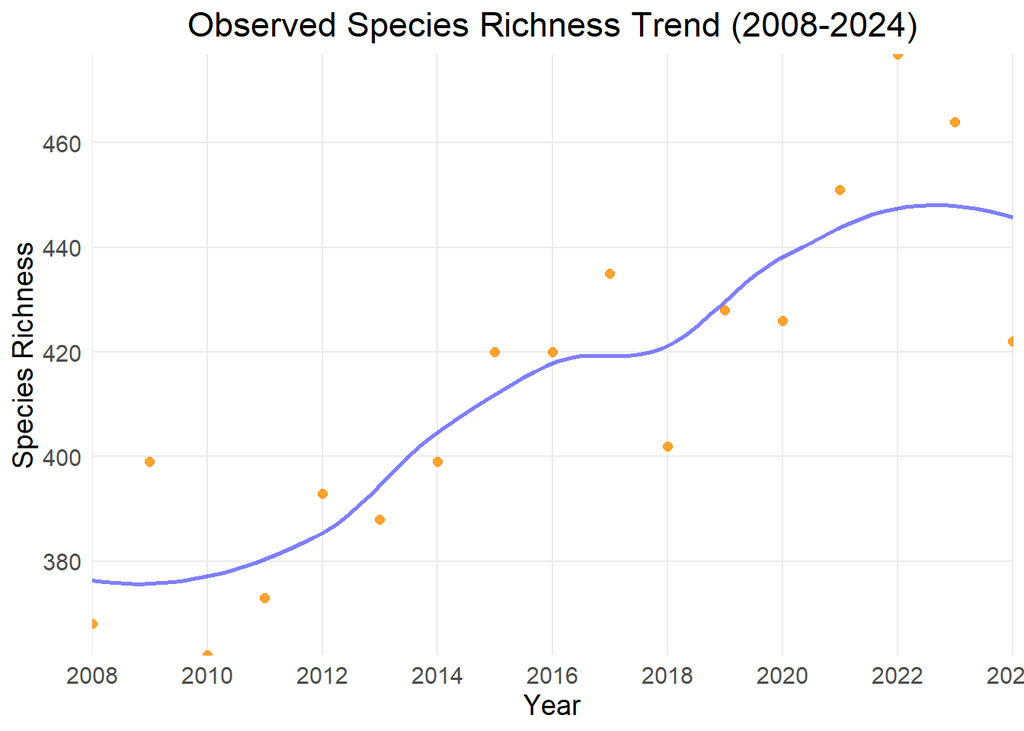

```r
plot(ts_map_obs_rich_WC)
```

### Number of records

```r
map_obs_WC <- total_occ_map(WCunstruc, cell_size = 0.08333333, level = "cube", region = "South Africa", ne_scale = "medium")
plot(map_obs_WC)
```

Above will not work as grid (pentads) is custom, cannot map results but can look at change over time

Below mapped records using other methods.

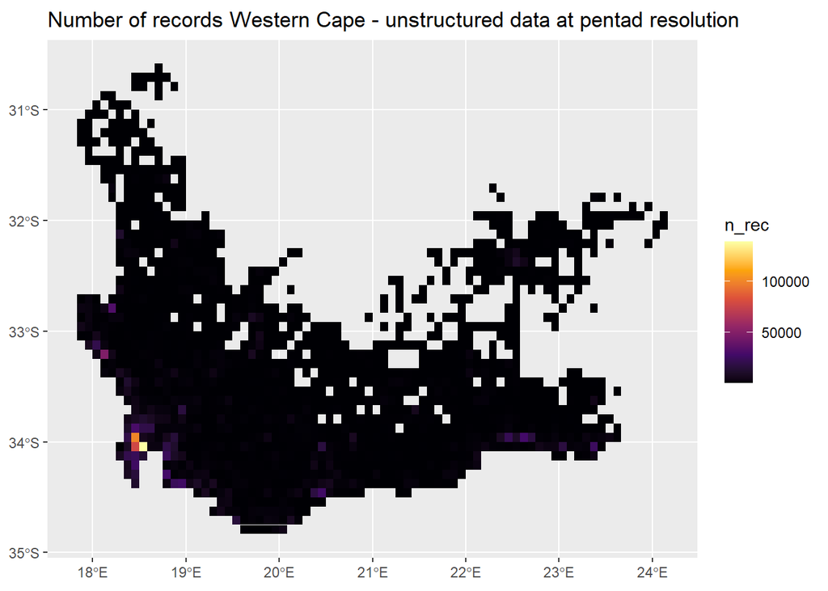

```r
UnstrucWCinterim %>% group_by(pentad) %>%
              summarise(n_rec = sum(n), .groups = "drop") %>%
  ggplot() +
    geom_sf(aes(fill = n_rec), col = alpha("white", 0)) +
    scale_fill_viridis_c(option = "inferno") +
    ggtitle("Number of records Western Cape - unstructured data at pentad resolution")
```

Change over time

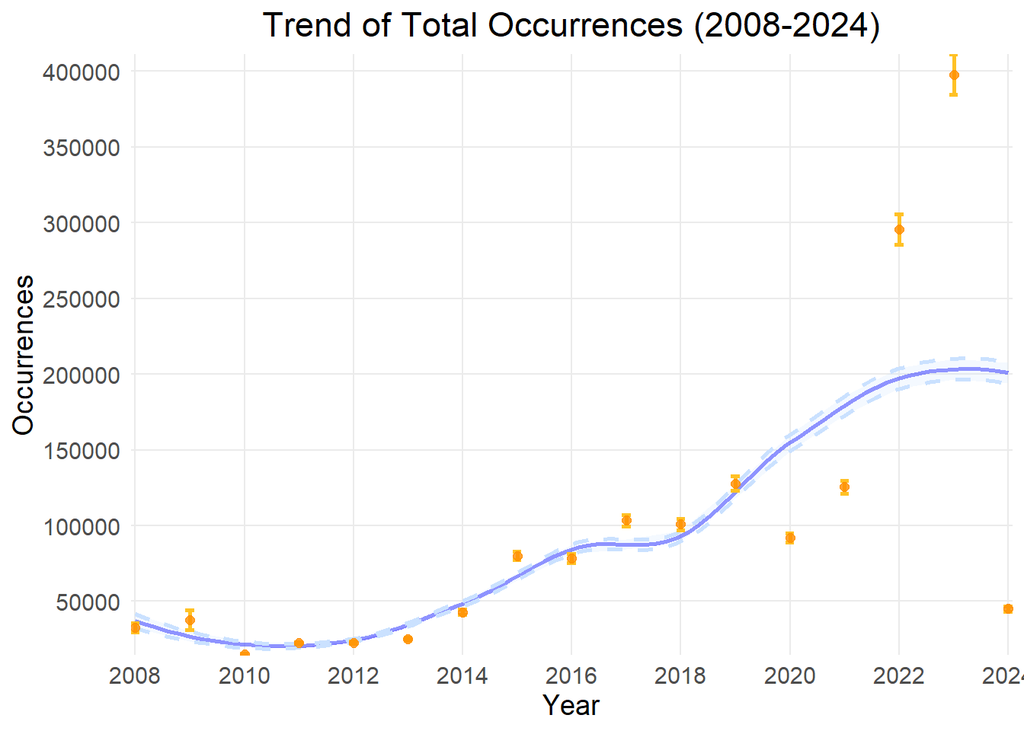

```r
ts_obs_WC <- total_occ_ts(WCunstruc, cell_size = 0.08333333, level = "cube", region = "South Africa", ne_scale = "medium")
plot(ts_obs_WC)
```

### Period 2008-2024 (SABAP2 species)

```r
# Process cube
WCunstrucSpp <- process_cube(UnstrucWCspp, grid_type = 'custom', first_year = '2008', cols_year =  'year', cols_cellCode = 'pentad', cols_occurrences = 'n',  cols_minCoordinateUncertaintyInMeters
= 'mincoordinateUncertaintyInMeters', cols_familyCount = 'familycount')
```

### Observed richness

```r
map_obs_rich_WC <- obs_richness_map(WCunstrucSpp, cell_size = 0.08333333, level = "cube", region = "South Africa", ne_scale = "medium")
plot(map_obs_rich_WC)
```

Above will not work as grid (pentads) is custom, cannot map results. Below mapped richness using other methods.

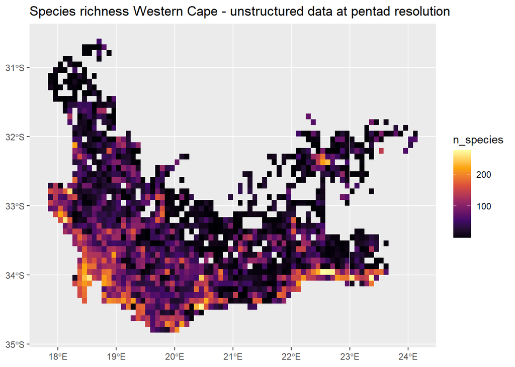

```r
UnstrucWCsppGeom %>% group_by(pentad) %>%
              summarise(n_species = n_distinct(species), .groups = "drop") %>%
  ggplot() +
    geom_sf(aes(fill = n_species), col = alpha("white", 0)) +
    scale_fill_viridis_c(option = "inferno") +
    ggtitle("Species richness Western Cape - unstructured data at pentad resolution")
```

Change over time

```r
ts_map_obs_rich_WC <- obs_richness_ts(WCunstrucSpp, cell_size = 0.08333333, level = "cube", region = "South Africa", ne_scale = "medium")
```

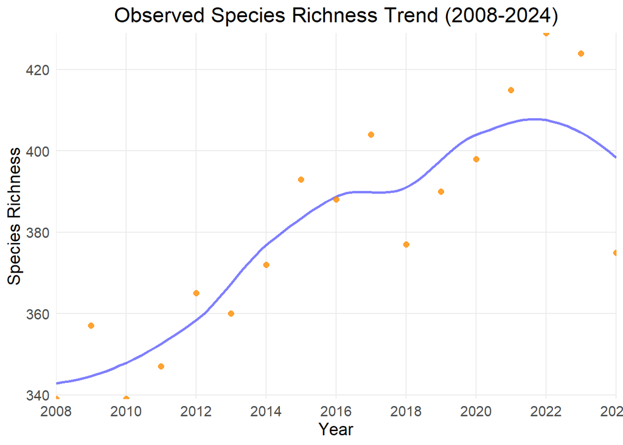

```r
plot(ts_map_obs_rich_WC)
```

### Number of records

```r
map_obs_WC <- total_occ_map(WCunstrucSpp, cell_size = 0.08333333, level = "cube", region = "South Africa", ne_scale = "medium")
plot(map_obs_WC)
```

Above will not work as grid (pentads) is custom, cannot map results but can look at change over time

Below mapped records using other methods.

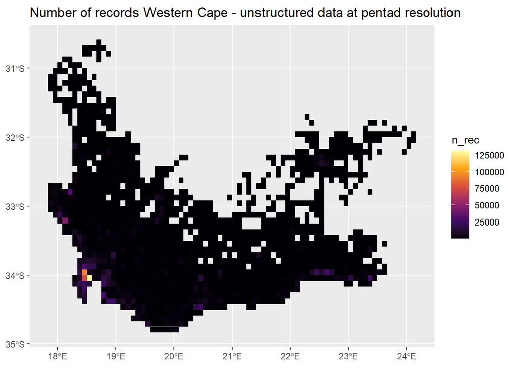

```r
UnstrucWCsppGeom %>% group_by(pentad) %>%
              summarise(n_rec = sum(n), .groups = "drop") %>%
  ggplot() +
    geom_sf(aes(fill = n_rec), col = alpha("white", 0)) +
    scale_fill_viridis_c(option = "inferno") +
    ggtitle("Number of records Western Cape - unstructured data at pentad resolution")
```

Change over time

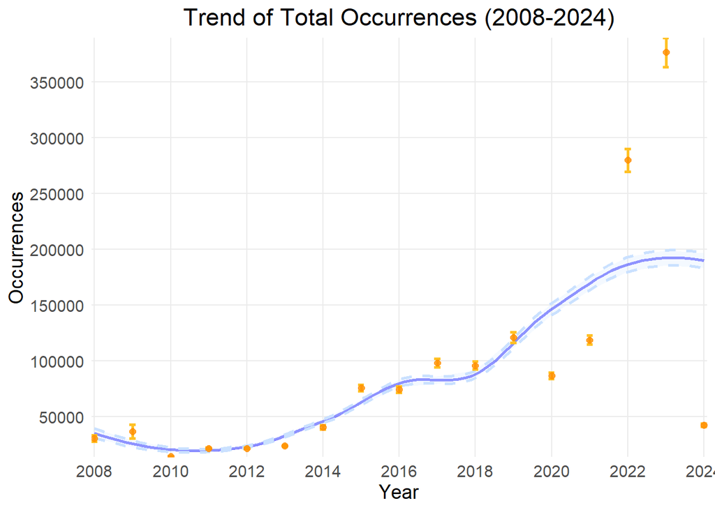

```r
ts_obs_WC<- total_occ_ts(WCunstrucSpp, cell_size = 0.08333333, level = "cube", region = "South Africa", ne_scale = "medium")
plot(ts_obs_WC)
```

## Structured SABAP2 data (2008-2024)

```r
# Process cube
WCSABAP2 <- process_cube(SABAP2WCGrp, grid_type = 'custom', first_year = '2008', cols_year =  'year', cols_cellCode = 'pentad', cols_occurrences = 'n')
```

### Observed richness

```r
map_obs_rich_SABAP2 <- obs_richness_map(WCSABAP2, cell_size = 0.08333333, level = "cube", region = "South Africa", ne_scale = "medium")
plot(map_obs_rich_SABAP2)
```

Above will not work as grid (pentads) is custom, cannot map results. Below mapped richness using other methods.

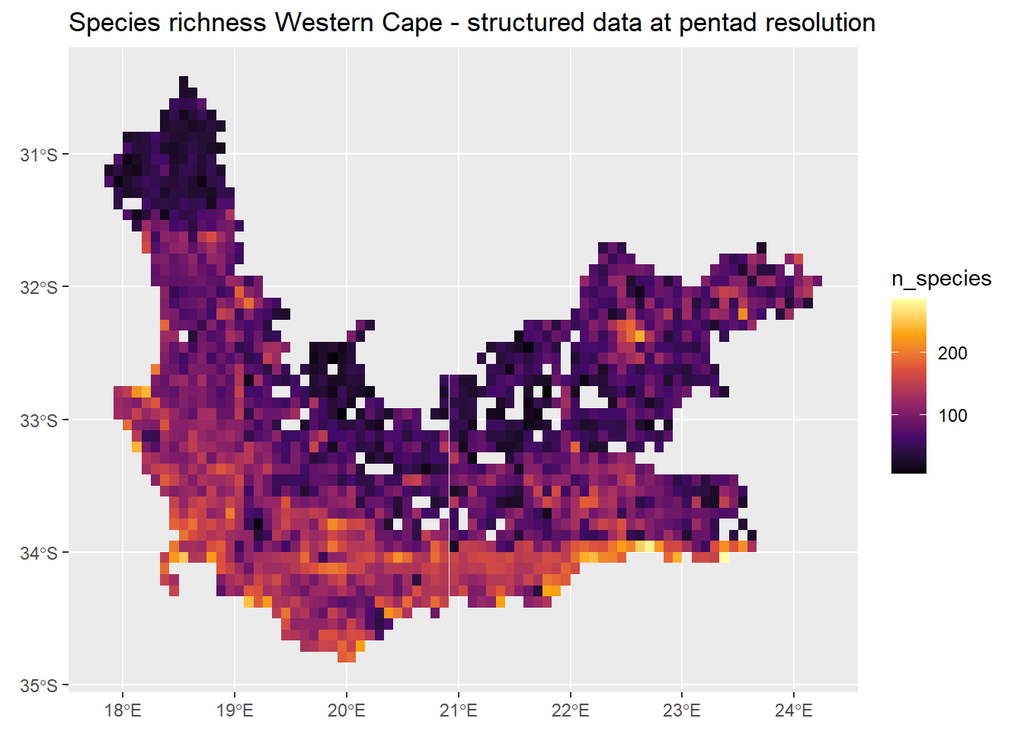

```r
SABAP2WCGeom %>% group_by(pentad) %>%
              summarise(n_species = n_distinct(species), .groups = "drop") %>%
  ggplot() +
    geom_sf(aes(fill = n_species), col = alpha("white", 0)) +
    scale_fill_viridis_c(option = "inferno") +
    ggtitle("Species richness Western Cape - structured data at pentad resolution")
```

change over time

```r
ts_obs_rich_SABAP2 <- obs_richness_ts(WCSABAP2, cell_size = 0.08333333, level = "cube", region = "South Africa", ne_scale = "medium")
```

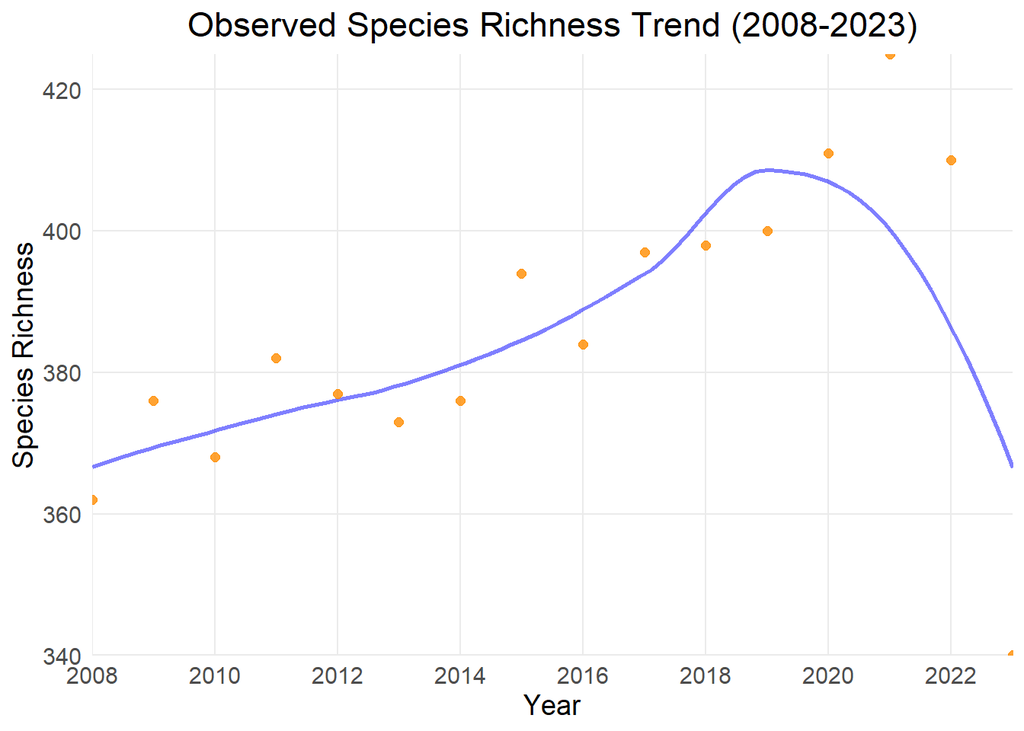

```r
plot(ts_obs_rich_SABAP2)
```

### Number of records

```r
map_obs_SABAP2 <- total_occ_map(WCSABAP2, cell_size = 0.08333333, level = "cube", region = "South Africa", ne_scale = "medium")
plot(map_obs_SABAP2)
```

Above will not work as grid (pentads) is custom, cannot map results but can look at change over time

Below mapped records using other methods.

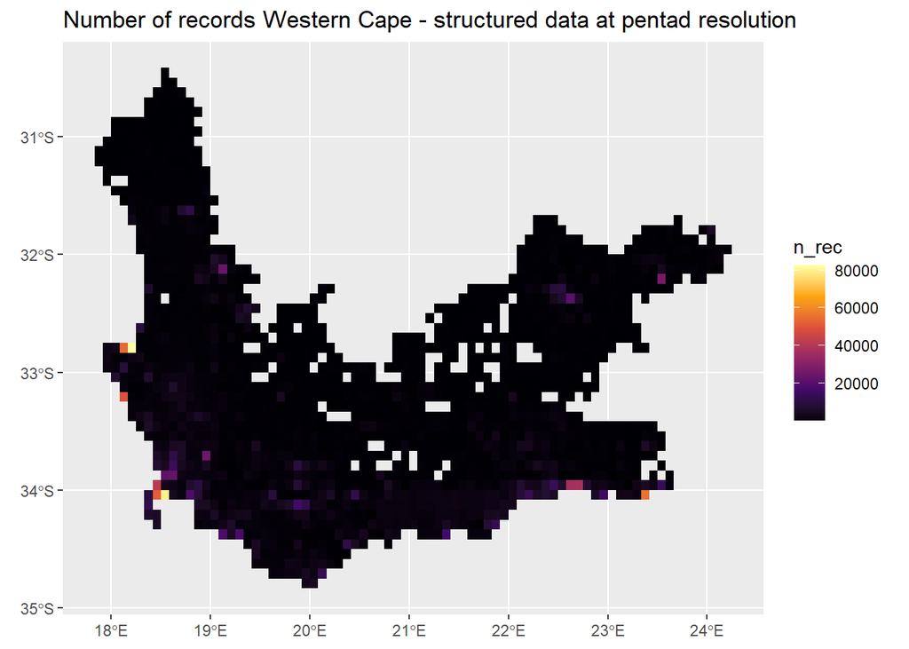

```r
SABAP2WCGeom %>% group_by(pentad) %>%
              summarise(n_rec = n(), .groups = "drop") %>%
  ggplot() +
    geom_sf(aes(fill = n_rec), col = alpha("white", 0)) +
    scale_fill_viridis_c(option = "inferno") +
    ggtitle("Number of records Western Cape - structured data at pentad resolution")
```

Change over time

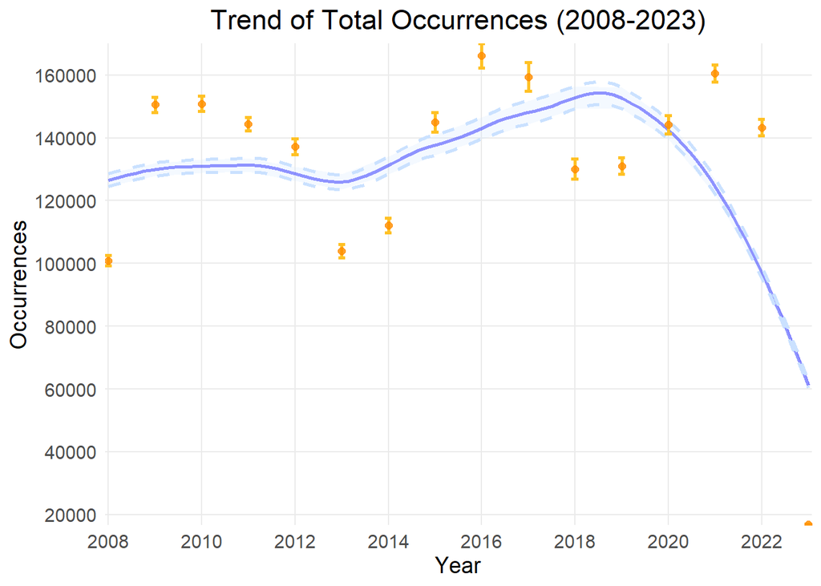

```r
ts_obs_SABAP2 <- total_occ_ts(WCSABAP2, cell_size = 0.08333333, level = "cube", region = "South Africa", ne_scale = "medium")
plot(ts_obs_SABAP2)
```

# Load QDGC scale data

## Structured data

### Occurrence data

The SABAP2 data were prepared and stored as a geopackage file in *./data/interim*.

We read in the dataset.

```r
# Read SABAP2 Western Cape bird data
SABAP2WCQDGCinterim <- read_sf(file.path(data_path, "SABAP2_QDGC_WC_data.gpkg"))

# Explore dataframe
glimpse(SABAP2WCQDGCinterim)
```

```
## Rows: 2,146,731
## Columns: 231
## $ qdgc                                <chr> "E017S32DD", "E017S32DD", "E017S32…
## $ level_qdgc                          <int> 2, 2, 2, 2, 2, 2, 2, 2, 2, 2, 2, 2…
## $ cellsize_degrees                    <dbl> 0.25, 0.25, 0.25, 0.25, 0.25, 0.25…
## $ lon_center                          <dbl> 17.875, 17.875, 17.875, 17.875, 17…
## $ lat_center                          <dbl> -32.875, -32.875, -32.875, -32.875…
## $ area_km2                            <dbl> 648.672, 648.672, 648.672, 648.672…
## $ gbifID                              <dbl> 2337480845, 2337772300, 2340597769…
## $ accessRights                        <lgl> NA, NA, NA, NA, NA, NA, NA, NA, NA…
## $ bibliographicCitation               <lgl> NA, NA, NA, NA, NA, NA, NA, NA, NA…
## $ language                            <lgl> NA, NA, NA, NA, NA, NA, NA, NA, NA…
## $ license                             <chr> "CC_BY_4_0", "CC_BY_4_0", "CC_BY_4…
## $ modified                            <lgl> NA, NA, NA, NA, NA, NA, NA, NA, NA…
## $ publisher                           <chr> "FitzPatrick Institute of African …
```

[output cut: 218 more lines]

## Unstructured data cube

Unstructured data from GBIF were prepared and stored as a geopackage file in *./data/interim*.

We read in the dataset.

```r
# Read unstructured Western Cape bird data
UnstrucWCQDGCinterim <- read_sf(file.path(data_path, "birdcube_QDGC_year_WC.gpkg"))

# Explore dataframe
glimpse(UnstrucWCQDGCinterim)
```

```
## Rows: 159,515
## Columns: 14
## $ qdgc                             <chr> "E017S33BB", "E017S33BB", "E017S33BB"…
## $ level_qdgc                       <int> 2, 2, 2, 2, 2, 2, 2, 2, 2, 2, 2, 2, 2…
## $ cellsize_degrees                 <dbl> 0.25, 0.25, 0.25, 0.25, 0.25, 0.25, 0…
## $ lon_center                       <dbl> 17.875, 17.875, 17.875, 17.875, 17.87…
## $ lat_center                       <dbl> -33.125, -33.125, -33.125, -33.125, -…
## $ area_km2                         <dbl> 646.8711, 646.8711, 646.8711, 646.871…
## $ year                             <dbl> 2008, 2008, 2008, 2008, 2009, 2009, 2…
## $ specieskey                       <dbl> 2492750, 5229203, 5229384, 6065817, 2…
## $ species                          <chr> "Prinia maculosa", "Bostrychia hageda…
## $ family                           <chr> "Cisticolidae", "Threskiornithidae", …
## $ n                                <dbl> 1, 1, 1, 1, 2, 1, 2, 3, 1, 1, 1, 1, 1…
## $ mincoordinateuncertaintyinmeters <dbl> 1000, 1000, 488, 295, 1000, 1000, 100…
## $ familycount                      <dbl> 95322, 87576, 7542, 119336, 9166, 815…
## $ geom                             <MULTIPOLYGON [°]> MULTIPOLYGON (((17.75 -3…
```

# Prepare data for indicators

Structured data from SABAP2 for birds recorded in pentads of Western Cape between 2008 and 2024. These data have been converted to QDGC. 247 QDGC cover the area.

It was noted that there were records where species was NA. They were removed below. There may be an issue with the data for certain species flowing into GBIF from SABAP2.

There is also a delay for data to flow into GBIF, so data for all of 2024 and most of 2023 not included in dataset.

```r
# Drop geometry, removed records not identified to species level
SABAP2WCQDGCGeom <-  SABAP2WCQDGCinterim %>%
  filter(!is.na(species))

SABAP2WCQDGC <-  SABAP2WCQDGCGeom %>% st_drop_geometry()

# Group by species, year and pentad
SABAP2WCQDGCGrp <-SABAP2WCQDGC %>%
   group_by(species, year, qdgc, speciesKey) %>%
    summarise(n = n())
glimpse(SABAP2WCQDGCGrp)
```

```
## Rows: 276,731
## Columns: 5
## Groups: species, year, qdgc [276,731]
## $ species    <chr> "Accipiter melanoleucus", "Accipiter melanoleucus", "Accipi…
## $ year       <dbl> 2008, 2008, 2008, 2008, 2008, 2008, 2008, 2008, 2008, 2008,…
## $ qdgc       <chr> "E018S32DA", "E018S33AD", "E018S33BA", "E018S33CD", "E018S3…
## $ speciesKey <dbl> 2480631, 2480631, 2480631, 2480631, 2480631, 2480631, 24806…
## $ n          <int> 1, 2, 1, 9, 9, 1, 10, 14, 24, 1, 2, 1, 4, 1, 8, 1, 1, 1, 3,…
```

Unstructured data from GBIF for birds recorded in pentads of Western Cape between 2008 and 2024. These data have been converted to QDGC scale. There are 247 QDGC in the area.

It was noted that there were a number of species included in the unstructured data that were not in the structured data. This was for a number of reasons including likely misidentifications, and also as for some species SABAP2 data does not seem to be flowing to GBIF.

Due to delays in data flowing into GBIF the data for 2024 are not complete.

```r
# Remove NAs and geometry
UnstrucWCQDGC<- UnstrucWCQDGCinterim %>%
  st_drop_geometry()
```

```r
# species recorded in sabap2
studied_spec <- unique(SABAP2WCQDGC$species) %>%
  na.omit()

UnstrucWCQDGCsppGeom <- UnstrucWCQDGCinterim %>%
  filter(species %in% studied_spec)

UnstrucWCQDGCspp <- UnstrucWCQDGCsppGeom %>%
  st_drop_geometry()
```

# Indicators

The indicators have been populated including/excluding species in unstructured data not included in SABAP2

## Unstructured data

### Period 2008-2024 (all species)

```r
# Process cube
WCunstrucQDGCproc <- process_cube(UnstrucWCQDGC, grid_type = 'eqdgc', first_year = '2008', cols_year =  'year', cols_cellCode = 'qdgc', cols_occurrences = 'n',  cols_minCoordinateUncertaintyInMeters
= 'mincoordinateuncertaintyinmeters', cols_familyCount = 'familycount', cols_speciesKey = 'specieskey')
```

### Observed richness

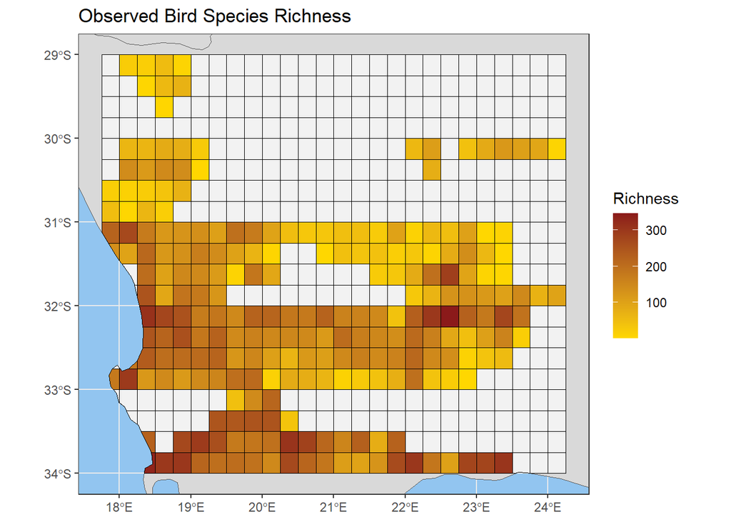

```r
map_obs_rich_WC_QDGC <- obs_richness_map(WCunstrucQDGCproc, cell_size = 0.25, level = "cube", region = "South Africa", ne_scale = "medium")
plot(map_obs_rich_WC_QDGC, title = "Observed Bird Species Richness")
```

Plots, but oddly. Possible issue with grid package uses.

Below mapped richness using other methods.

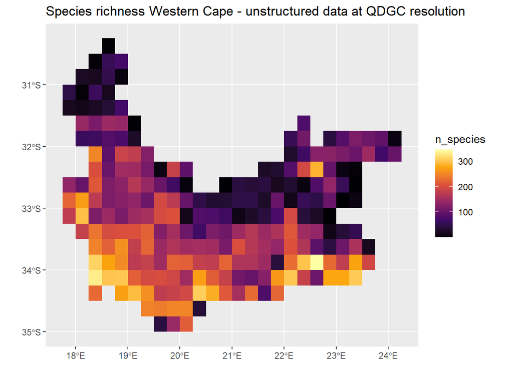

```r
UnstrucWCQDGCinterim %>% group_by(qdgc) %>%
  summarise(n_species = n_distinct(species), .groups = "drop") %>%
  ggplot() +
  geom_sf(aes(fill = n_species), col = alpha("white", 0)) +
  scale_fill_viridis_c(option = "inferno") +
  ggtitle("Species richness Western Cape - unstructured data at QDGC resolution")
```

Changes over time

```r
ts_map_obs_rich_WC_QDGC <- obs_richness_ts(WCunstrucQDGCproc, cell_size = 0.25, level = "cube", region = "South Africa", ne_scale = "medium")
```

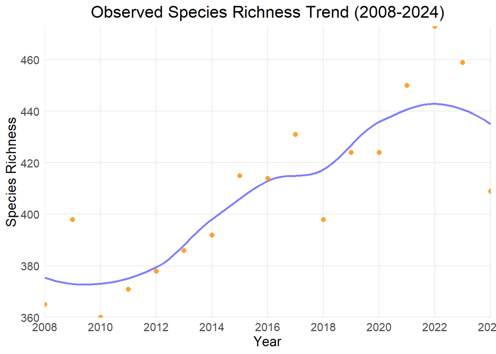

```r
plot(ts_map_obs_rich_WC_QDGC)
```

### Number of records

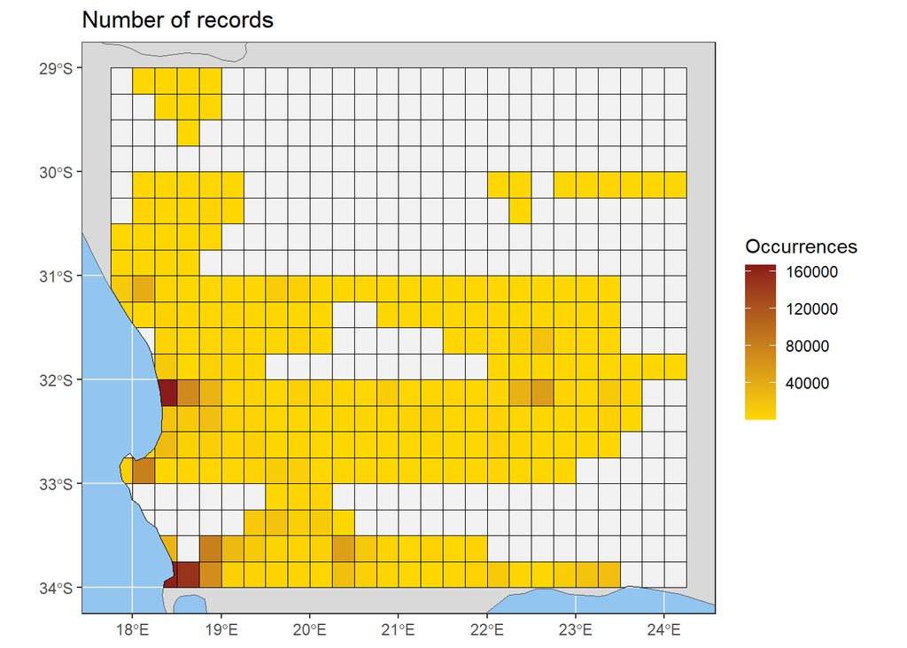

```r
map_obs_WC_QDGC <- total_occ_map(WCunstrucQDGCproc, cell_size = 0.25, level = "cube", region = "South Africa", ne_scale = "medium")
plot(map_obs_WC_QDGC, title = "Number of records")
```

Plots, but oddly. Possible issue with grid package uses.

Below mapped number of records using other methods.

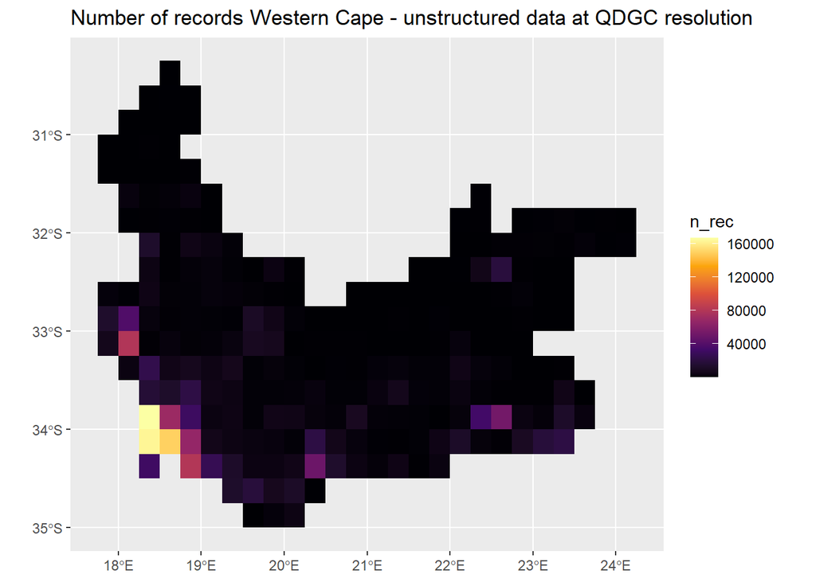

```r
UnstrucWCQDGCinterim %>% group_by(qdgc) %>%
  summarise(n_rec = sum(n), .groups = "drop") %>%
  ggplot() +
  geom_sf(aes(fill = n_rec), col = alpha("white", 0)) +
  scale_fill_viridis_c(option = "inferno") +
  ggtitle("Number of records Western Cape - unstructured data at QDGC resolution")
```

Changes over time

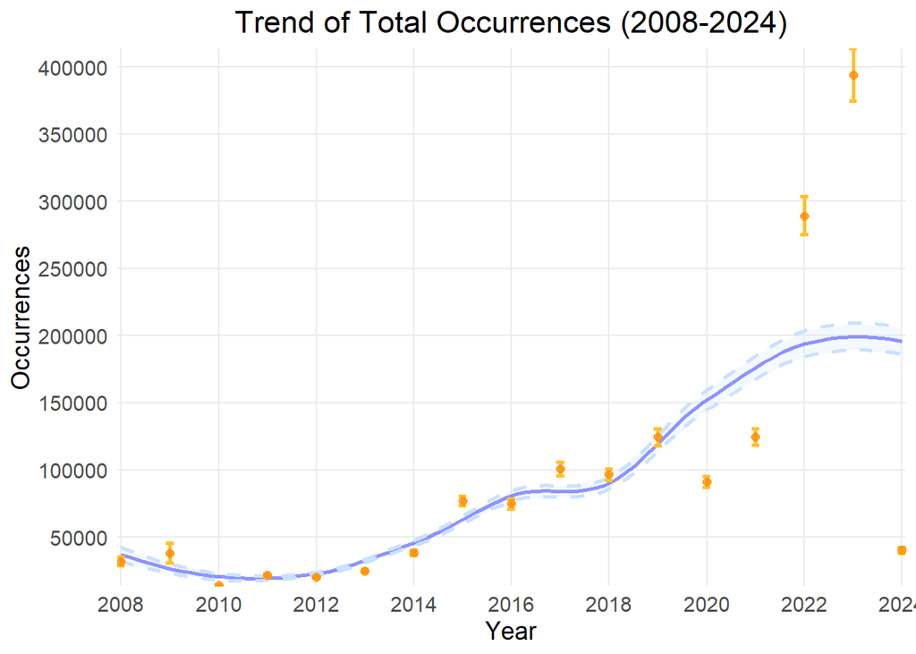

```r
ts_obs_WC_QDGC <- total_occ_ts(WCunstrucQDGCproc, cell_size = 0.25, level = "cube", region = "South Africa", ne_scale = "medium")
plot(ts_obs_WC_QDGC)
```

### Period 2008-2024 (SABAP2 species)

```r
# Process cube
WCunstrucQDGCsppproc <- process_cube(UnstrucWCQDGCspp, grid_type = 'eqdgc', first_year = '2008', cols_year =  'year', cols_cellCode = 'qdgc', cols_occurrences = 'n',  cols_minCoordinateUncertaintyInMeters
= 'mincoordinateuncertaintyinmeters', cols_familyCount = 'familycount', cols_speciesKey = 'specieskey')
```

### Observed richness

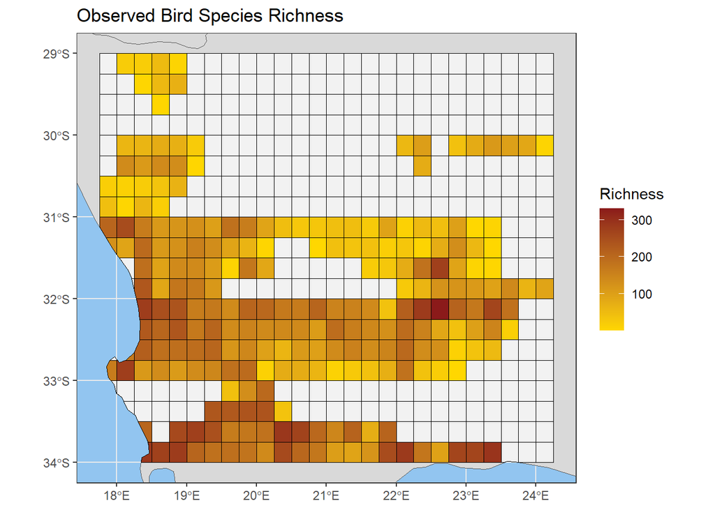

```r
map_obs_rich_WC_QDGC <- obs_richness_map(WCunstrucQDGCsppproc, cell_size = 0.25, level = "cube", region = "South Africa", ne_scale = "medium")
plot(map_obs_rich_WC_QDGC, title = "Observed Bird Species Richness")
```

Plots, but oddly. Possible issue with grid package uses.

Below mapped richness using other methods.

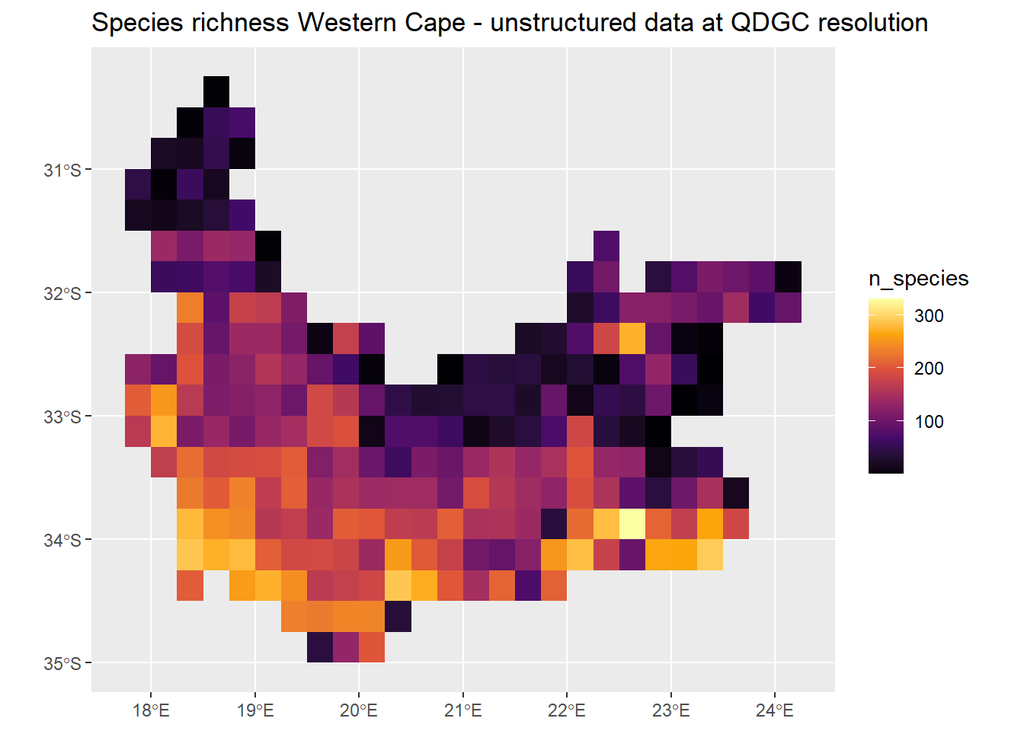

```r
UnstrucWCQDGCsppGeom %>% group_by(qdgc) %>%
  summarise(n_species = n_distinct(species), .groups = "drop") %>%
  ggplot() +
  geom_sf(aes(fill = n_species), col = alpha("white", 0)) +
  scale_fill_viridis_c(option = "inferno") +
  ggtitle("Species richness Western Cape - unstructured data at QDGC resolution")
```

Changes over time

```r
ts_map_obs_rich_WC_QDGC <- obs_richness_ts(WCunstrucQDGCsppproc, cell_size = 0.25, level = "cube", region = "South Africa", ne_scale = "medium")
```

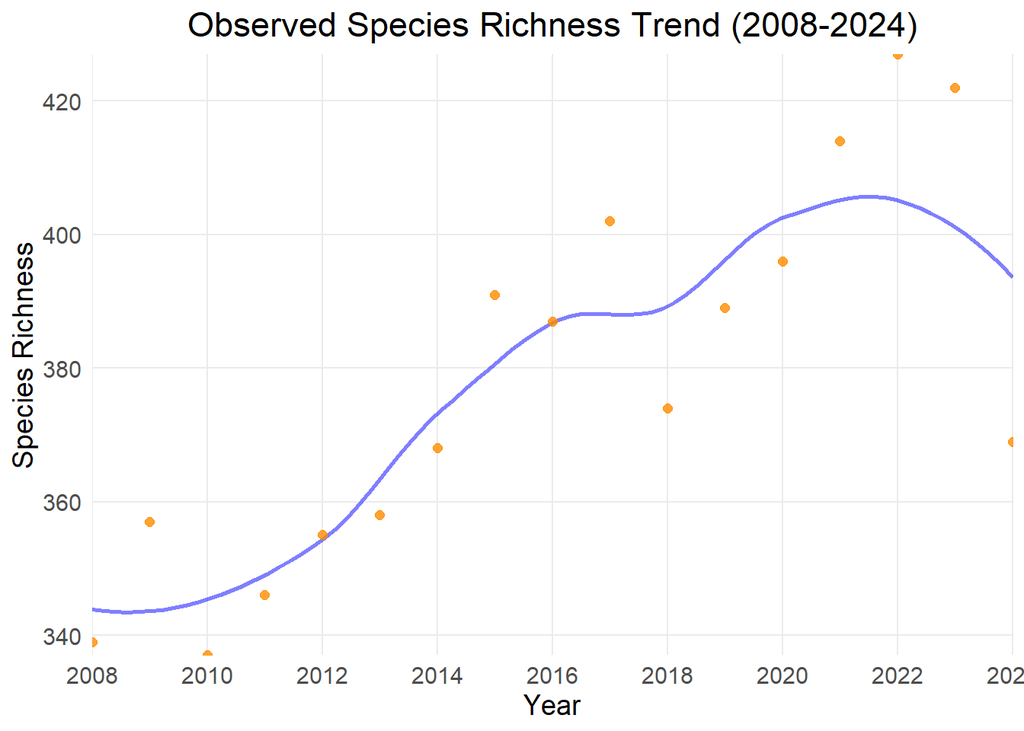

```r
plot(ts_map_obs_rich_WC_QDGC)
```

### Number of records

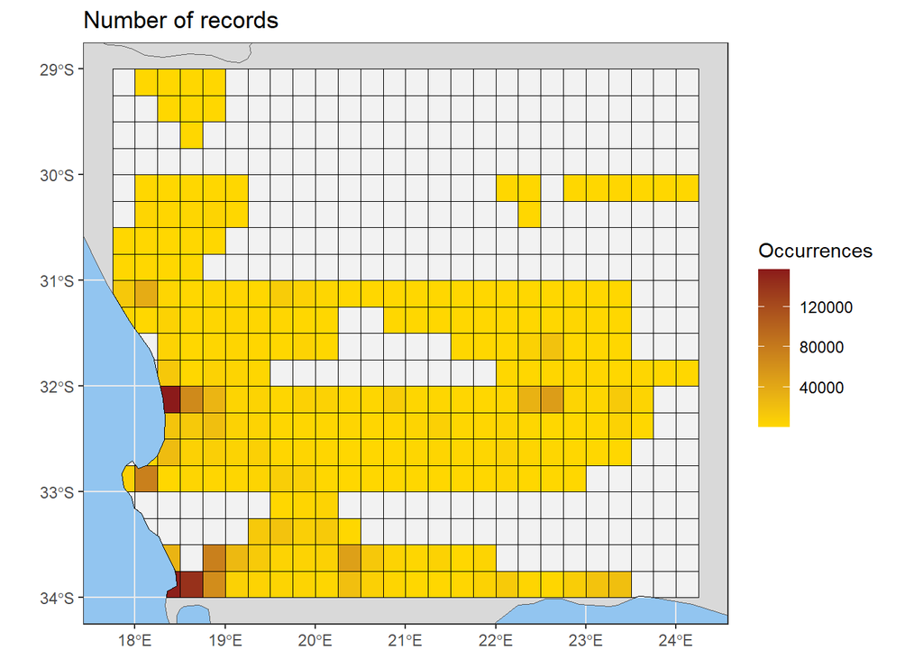

```r
map_obs_WC_QDGC <- total_occ_map(WCunstrucQDGCsppproc, cell_size = 0.25, level = "cube", region = "South Africa", ne_scale = "medium")
plot(map_obs_WC_QDGC, title = "Number of records")
```

Plots, but oddly. Possible issue with grid package uses.

Below mapped number of records using other methods.

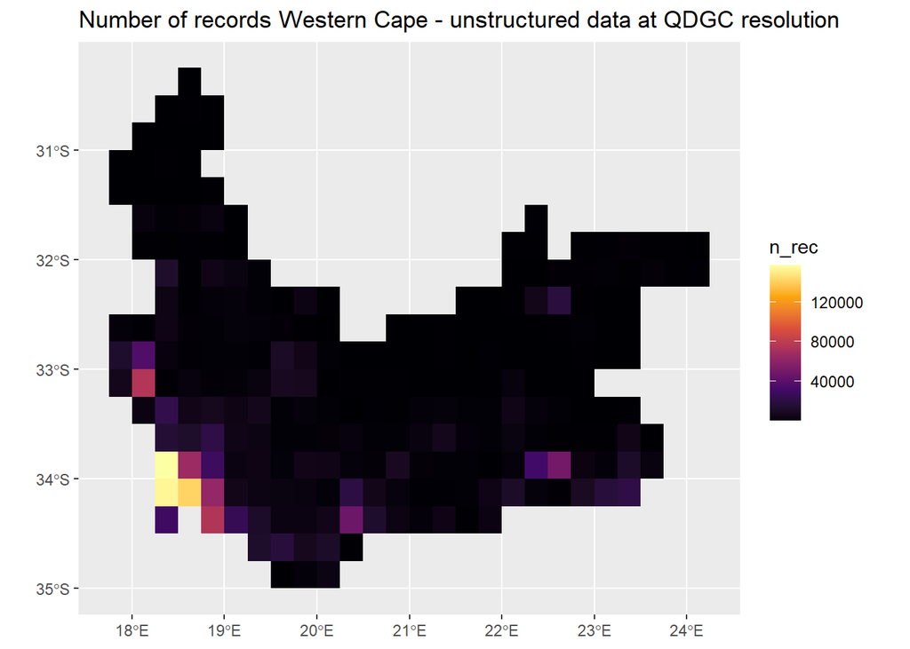

```r
UnstrucWCQDGCsppGeom %>% group_by(qdgc) %>%
  summarise(n_rec = sum(n), .groups = "drop") %>%
  ggplot() +
  geom_sf(aes(fill = n_rec), col = alpha("white", 0)) +
  scale_fill_viridis_c(option = "inferno") +
  ggtitle("Number of records Western Cape - unstructured data at QDGC resolution")
```

Changes over time

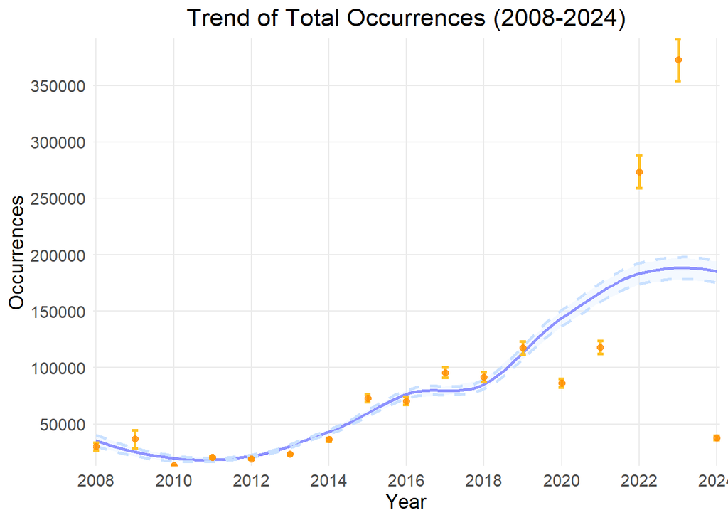

```r
ts_obs_WC_QDGC <- total_occ_ts(WCunstrucQDGCsppproc, cell_size = 0.25, level = "cube", region = "South Africa", ne_scale = "medium")
plot(ts_obs_WC_QDGC)
```

## Structured SABAP2 data

```r
# Process cube
WCSABAP2QDGC <- process_cube(SABAP2WCQDGCGrp, grid_type = 'eqdgc', first_year = '2008', cols_year =  'year', cols_cellCode = 'qdgc', cols_occurrences = 'n')
```

### Observed richness

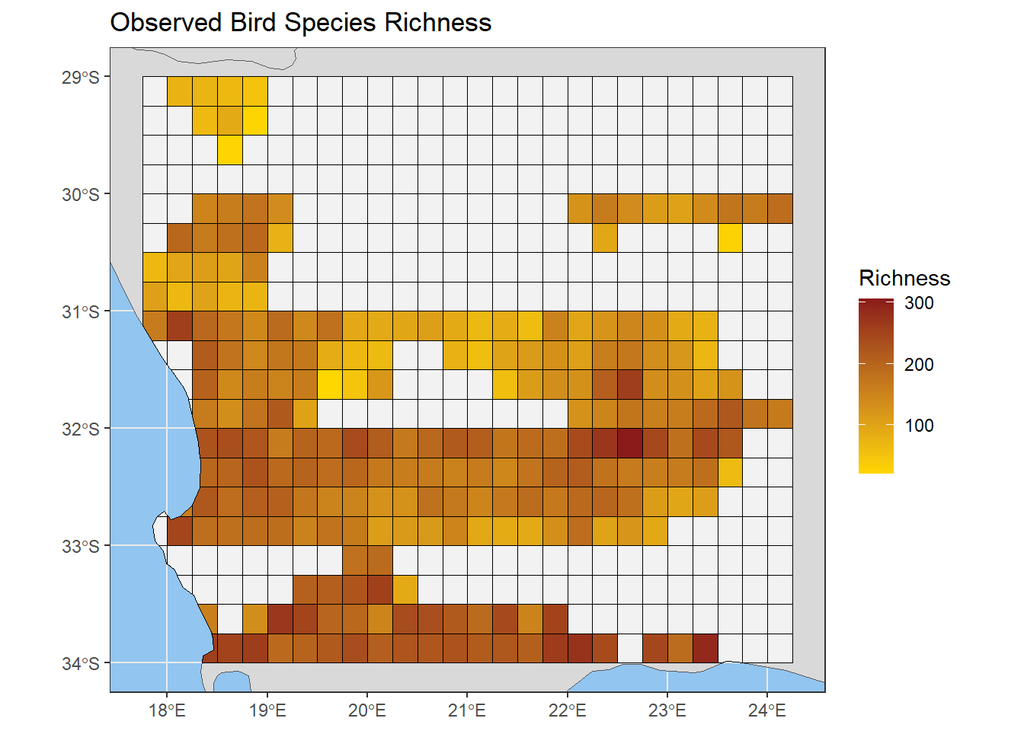

```r
map_obs_rich_SABAP2_QDGC <- obs_richness_map(WCSABAP2QDGC, cell_size = 0.25, level = "cube", region = "South Africa", ne_scale = "medium")
plot(map_obs_rich_SABAP2_QDGC, title = "Observed Bird Species Richness")
```

Plots, but oddly. Possible issue with grid package uses.

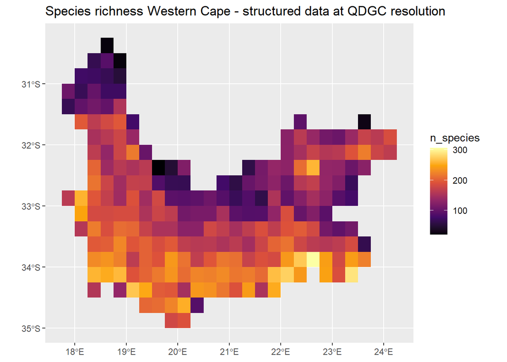

```r
SABAP2WCQDGCGeom %>% group_by(qdgc) %>%
  summarise(n_species = n_distinct(species), .groups = "drop") %>%
  ggplot() +
  geom_sf(aes(fill = n_species), col = alpha("white", 0)) +
  scale_fill_viridis_c(option = "inferno") +
  ggtitle("Species richness Western Cape - structured data at QDGC resolution")
```

Changes over time

```r
ts_obs_rich_SABAP2_QDGC <- obs_richness_ts(WCSABAP2QDGC, cell_size = 0.25, level = "cube", region = "South Africa", ne_scale = "medium")
```

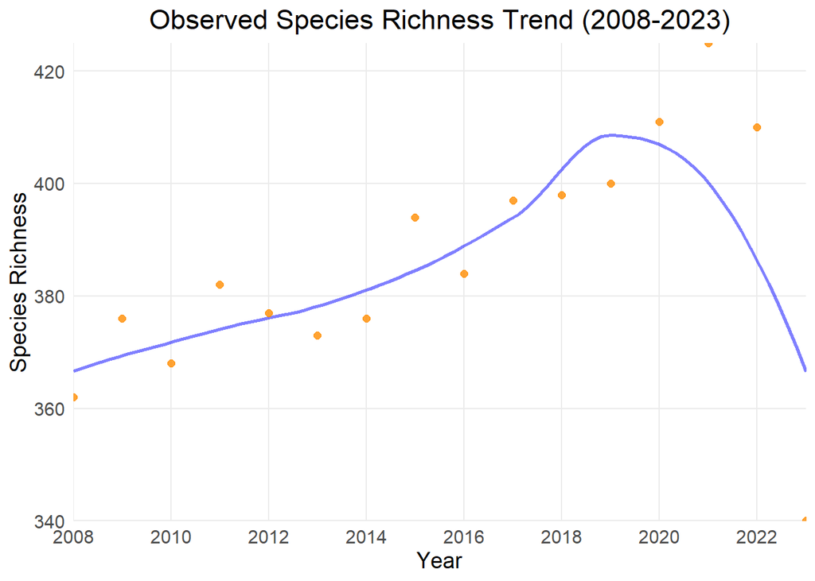

```r
plot(ts_obs_rich_SABAP2_QDGC)
```

### Number of records

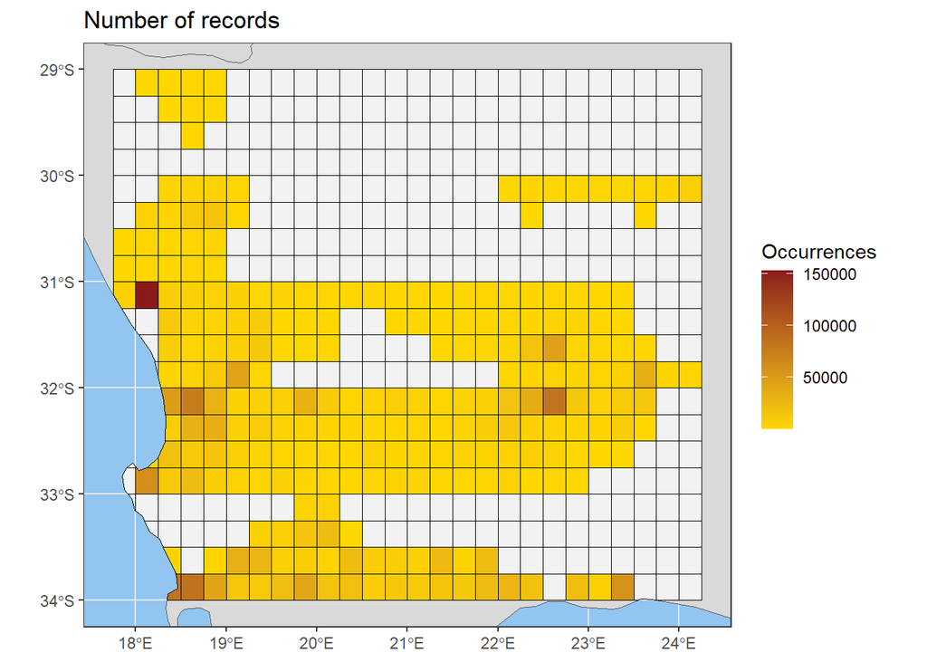

```r
map_obs_SABAP2_QDGC <- total_occ_map(WCSABAP2QDGC, cell_size = 0.25, level = "cube", region = "South Africa", ne_scale = "medium")
plot(map_obs_SABAP2_QDGC, title = "Number of records")
```

Plots, but oddly. Possible issue with grid package uses.

Below mapped number of records using other methods.

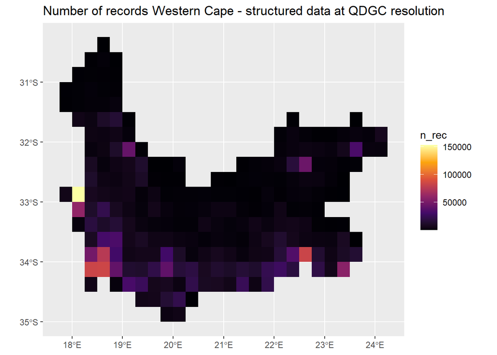

```r
SABAP2WCQDGCGeom %>% group_by(qdgc) %>%
  summarise(n_rec = n(), .groups = "drop") %>%
  ggplot() +
  geom_sf(aes(fill = n_rec), col = alpha("white", 0)) +
  scale_fill_viridis_c(option = "inferno") +
  ggtitle("Number of records Western Cape - structured data at QDGC resolution")
```

Changes over time

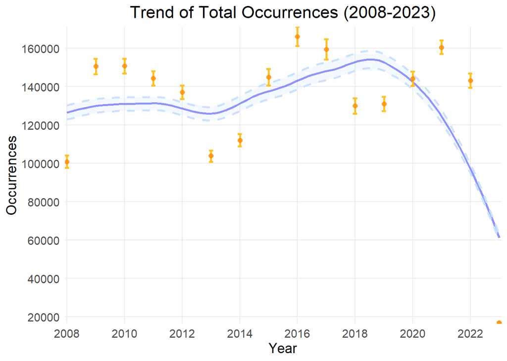

```r
ts_obs_SABAP2_QDGC <- total_occ_ts(WCSABAP2QDGC, cell_size = 0.25, level = "cube", region = "South Africa", ne_scale = "medium")
plot(ts_obs_SABAP2_QDGC)
```